# OPT-Neuro Motion Report

This summarizes the MRIQC metrics for framewise displacement, a measure of motion, in OPT-Neuro. It is only examining resting state fMRI scans. This document does not report the quality of structural scans.

The chart below shows how the percentage of scan timepoints above the 0.5mm threshold has changed over time. Each dot represents one run in the scanner - a participant usually has two runs per timepoint. The vertical line represents the date of the RA call to discuss strategies to mitigate in-scanner motion.

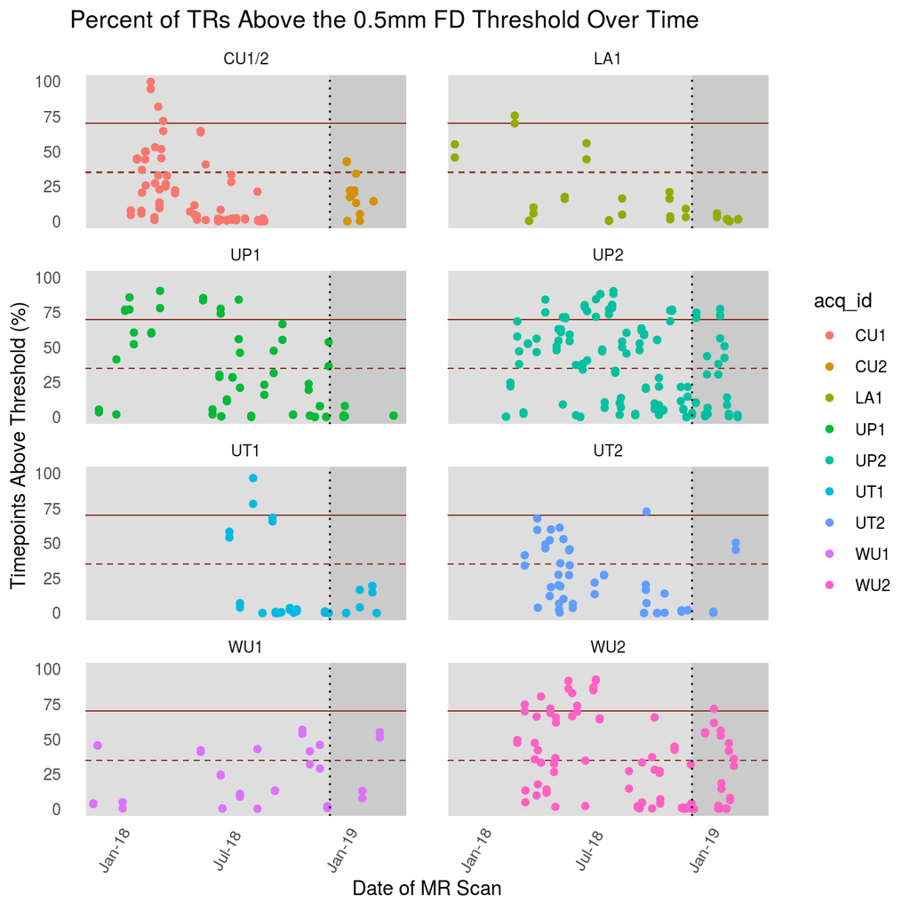

This table summarizes the median framewise displacements, as well as the median percent above threshold, for each scanner:

| Scanner | Median FD (SD) | Median FD % Above 0.5mm (SD) |
| --- | --- | --- |
| **CU** |  |  |
| CU1 | 0.19(0.23) | 9.3(25.46) |
| CU2 | 0.32(0.12) | 17.57(13.41) |
| **LA** |  |  |
| LA1 | 0.2(0.07) | 5.11(22.56) |
| **UP** |  |  |
| UP1 | 0.28(0.15) | 22.07(30.94) |
| UP2 | 0.32(0.22) | 39.39(29.38) |
| **UT** |  |  |
| UT1 | 0.17(0.39) | 1.02(27.14) |
| UT2 | 0.25(0.09) | 19.08(21.91) |
| **WU** |  |  |
| WU1 | 0.22(0.14) | 18.55(20.26) |
| WU2 | 0.29(0.16) | 31.38(29.83) |

This demonstrates how the mean framewise displacement has changed over time:

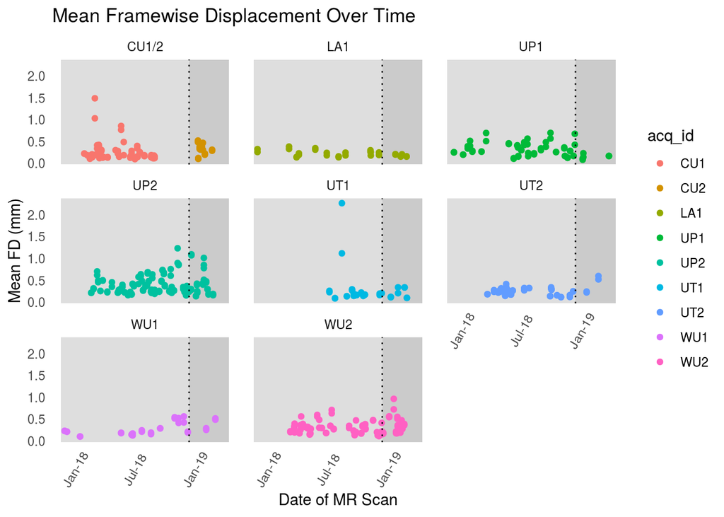